# EVT of Non-Stationary Data (Assume Independence)

Rishikesh Yadav

2024-08-02

## Data Loading and Preprocessing

```r
# Load the data
data(rain)
rain_data <- data.frame(date = seq.Date(from = as.Date("1914-01-01"),
                                        to = as.Date("1961-12-30"), by = "day"),
                        rainfall = rain)
summary(rain_data$rainfall)
```

```
##    Min. 1st Qu.  Median    Mean 3rd Qu.    Max.
##   0.000   0.000   0.500   3.476   4.300  86.600
```

## Extracting Yearly Maxima

```r
# Extract yearly maxima
rain_data_y <- rain_data %>%
  mutate(year = year(date)) %>%
  group_by(year) %>%
  summarize(max_rainfall = max(rainfall, na.rm = TRUE)) %>%
  ungroup()
head(rain_data_y)
```

```
## # A tibble: 6 × 2
##    year max_rainfall
##   <dbl>        <dbl>
## 1  1914         44.5
## 2  1915         43.2
## 3  1916         38.1
## 4  1917         39.1
## 5  1918         32.3
## 6  1919         25.4
```

## Detecting Trend in Yearly Maxima

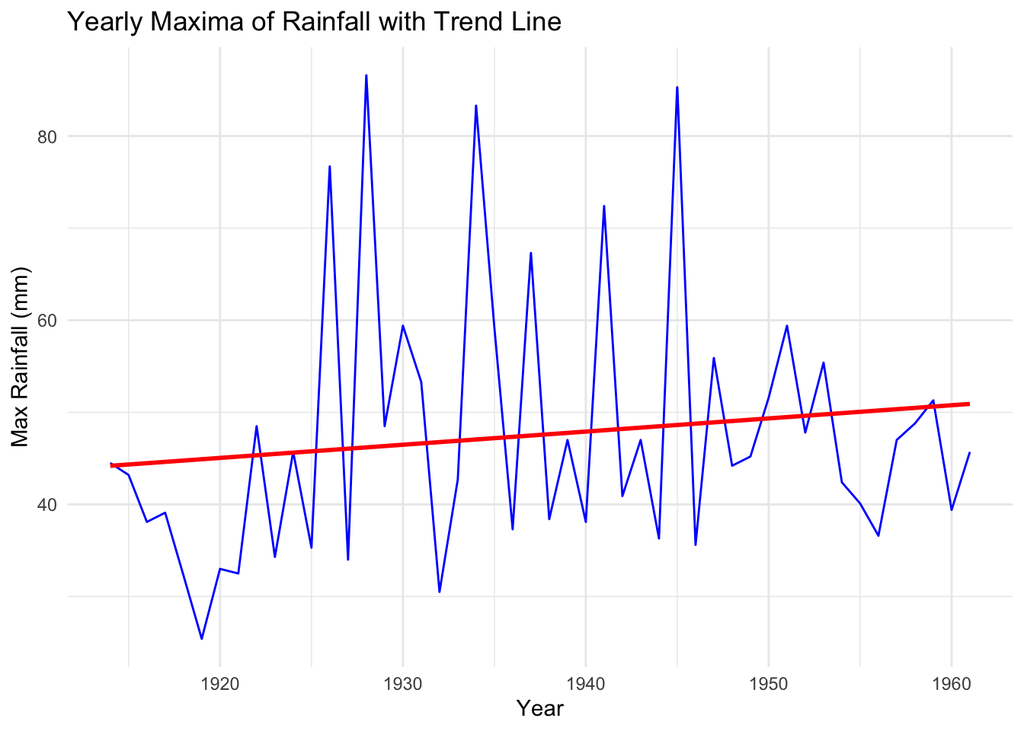

```r
# Plot yearly maxima to visually inspect for trend
ggplot(rain_data_y, aes(x = year, y = max_rainfall)) +
  geom_line(color = 'blue') +
  geom_smooth(method = 'lm', se = FALSE, color = 'red') +
  labs(title = "Yearly Maxima of Rainfall with Trend Line", x = "Year", y = "Max Rainfall (mm)") +
  theme_minimal()
```

```r
# Fit a linear model to detect trend
trend_model <- lm(max_rainfall ~ year, data = rain_data_y)
summary(trend_model)
```

```
##
## Call:
## lm(formula = max_rainfall ~ year, data = rain_data_y)
##
## Residuals:
##     Min      1Q  Median      3Q     Max
## -19.507 -10.144  -3.669   3.781  40.406
##
## Coefficients:
##              Estimate Std. Error t value Pr(>|t|)
## (Intercept) -229.5176   291.1759  -0.788    0.435
## year           0.1430     0.1503   0.952    0.346
##
## Residual standard error: 14.42 on 46 degrees of freedom
## Multiple R-squared:  0.0193, Adjusted R-squared:  -0.002015
## F-statistic: 0.9055 on 1 and 46 DF,  p-value: 0.3463
```

**Interpretation**:

The plot shows the yearly maxima of rainfall along with a linear trend line. The summary of the linear model provides information on the presence of any significant trend in the yearly maxima.

## Fitting GEV Models

### Without Trend Component

```r
# Fit GEV model without trend
gev_no_trend <- fevd(rain_data_y$max_rainfall, type = "GEV")
sumry_no_trend<- summary(gev_no_trend)
```

```
##
## fevd(x = rain_data_y$max_rainfall, type = "GEV")
##
## [1] "Estimation Method used: MLE"
##
##
##  Negative Log-Likelihood Value:  188.0154
##
##
##  Estimated parameters:
##   location      scale      shape
## 40.7830335  9.7284060  0.1072355
##
##  Standard Error Estimates:
##  location     scale     shape
## 1.5759687 1.1884175 0.1085659
##
##  Estimated parameter covariance matrix.
##            location       scale       shape
## location  2.4836774  0.89366862 -0.05358220
## scale     0.8936686  1.41233609 -0.01690982
## shape    -0.0535822 -0.01690982  0.01178655
##
##  AIC = 382.0309
##
##  BIC = 387.6445
```

### With Trend Component

```r
# Fit GEV model with trend
gev_with_trend <- fevd(rain_data_y$max_rainfall, data = rain_data_y,
                       location.fun = ~ year, type = "GEV")
sumry_with_trend<- summary(gev_with_trend)
```

```
##
## fevd(x = rain_data_y$max_rainfall, data = rain_data_y, location.fun = ~year,
##     type = "GEV")
##
## [1] "Estimation Method used: MLE"
##
##
##  Negative Log-Likelihood Value:  186.4476
##
##
##  Estimated parameters:
##           mu0           mu1         scale         shape
## -118.93629423    0.08191039    8.03740986    0.16124375
##
##  AIC = 380.8951
##
##  BIC = 388.3799
```

## Comparison of Fits

```r
# Compare AIC values
data.frame(Model = c("No Trend", "With Trend"), AIC = c(sumry_no_trend$AIC, sumry_with_trend$AIC))
```

```
##        Model      AIC
## 1   No Trend 382.0309
## 2 With Trend 380.8951
```

**Interpretation**:

The Akaike Information Criterion (AIC) values for the GEV models with and without trend components help us compare the models. The model with the lower AIC value is preferred.

## Diagnostic Plots

### Without Trend Component

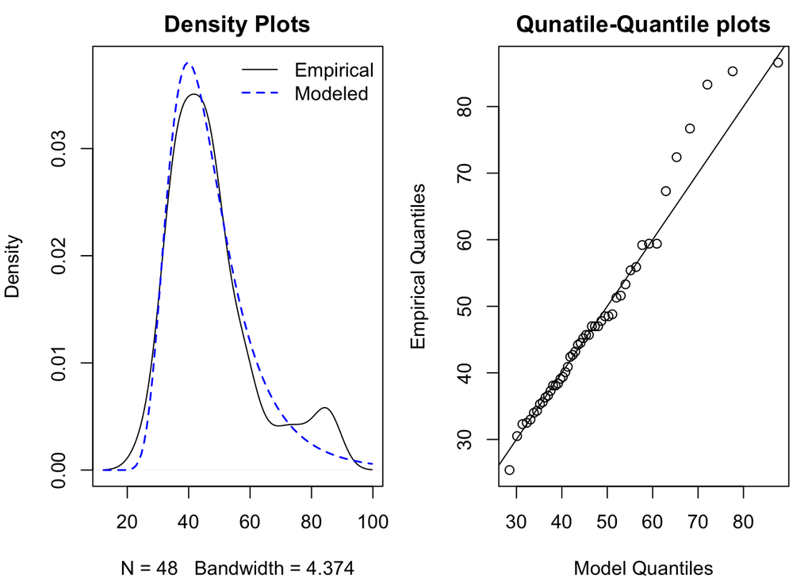

```r
# Diagnostic plots for GEV model without trend
par(mfrow = c(1, 2), mar = c(4, 4, 2, 1))
plot(gev_no_trend, "density", main=c("Density Plots"))
plot(gev_no_trend, "qq", main=c("Qunatile-Quantile plots"))
```

### With Trend Component

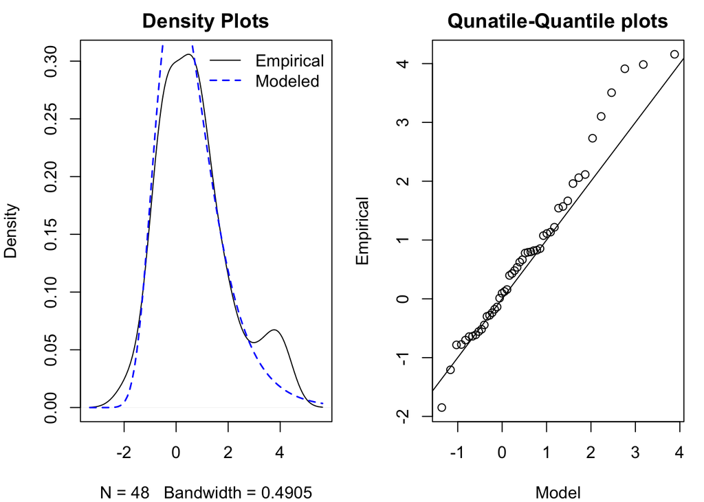

```r
# Diagnostic plots for GEV model with trend
par(mfrow = c(1, 2), mar = c(4, 4, 2, 1))
plot(gev_with_trend, "density", main=c("Density Plots"))
plot(gev_with_trend, "qq", main=c("Qunatile-Quantile plots"))
```

## Conclusion

The analysis of yearly maxima of rainfall data indicates whether there is a significant trend over time. By fitting GEV models with and without trend components, we assess the significance of the trend. The AIC values and diagnostic plots help us compare the models and determine the best fit.

# Fitting GPD Models

## Without Trend Component

```r
# Set a threshold for GPD
threshold <- quantile(rain_data$rainfall, 0.95, na.rm = TRUE)

# Extract exceedances over the threshold
exceedances <- rain_data %>%
  filter(rainfall > threshold) %>%
  mutate(year = year(date))
exceedances$rainfall<- exceedances$rainfall - threshold
# Fit GPD model without trend
gpd_no_trend <- fevd(exceedances$rainfall, threshold = 0, type = "GP")
summry_no_trend<- summary(gpd_no_trend)
```

```
##
## fevd(x = exceedances$rainfall, threshold = 0, type = "GP")
##
## [1] "Estimation Method used: MLE"
##
##
##  Negative Log-Likelihood Value:  2625.664
##
##
##  Estimated parameters:
##      scale      shape
## 7.93659982 0.03949179
##
##  Standard Error Estimates:
##      scale      shape
## 0.37045156 0.03155403
##
##  Estimated parameter covariance matrix.
##              scale         shape
## scale  0.137234357 -0.0075162616
## shape -0.007516262  0.0009956568
##
##  AIC = 5255.328
##
##  BIC = 5264.805
```

## With Trend Component

```r
# Fit GPD model with trend
gpd_with_trend <- fevd(exceedances$rainfall, threshold = 0, type = "GP", data = exceedances,
                       scale.fun = ~ year)
summry_with_trend<- summary(gpd_with_trend)
```

```
##
## fevd(x = exceedances$rainfall, data = exceedances, threshold = 0,
##     scale.fun = ~year, type = "GP")
##
## [1] "Estimation Method used: MLE"
##
##
##  Negative Log-Likelihood Value:  2625.271
##
##
##  Estimated parameters:
##       sigma0       sigma1        shape
## -21.97152860   0.01543612   0.03657707
##
##  Standard Error Estimates:
##      sigma0      sigma1       shape
## 1.712405253 0.000721725 0.031090736
##
##  Estimated parameter covariance matrix.
##              sigma0        sigma1         shape
## sigma0  2.932331751 -1.206766e-03 -1.068174e-02
## sigma1 -0.001206766  5.208870e-07  1.435833e-06
## shape  -0.010681739  1.435833e-06  9.666339e-04
##
##  AIC = 5256.542
##
##  BIC = 5270.757
```

#Comparison of Fits

```r
# Compare AIC values
data.frame(Model = c("No Trend", "With Trend"), AIC = c(summry_no_trend$AIC, summry_with_trend$AIC))
```

```
##        Model      AIC
## 1   No Trend 5255.328
## 2 With Trend 5256.542
```